# Download the GLC30 product for Peru and Ecuador

Cesar Aybar

2019-10-10

[figure not shown]

Land Cover information is fundamental for environmental change studies, land resource management, sustainable development, and many other societal benefits. In **Google Earth Engine** existing different coarse Land use/cover products (e.g. MCD12Q1-500m) that are not able to capture the most significant human impacts on land systems due to its spatial resolution. Therefore, this short post aims to introduce and explain step by step how to download the [GLC30](https://reader.elsevier.com/reader/sd/pii/S0924271614002275?token=BF89D29031101CDB800927F3DA0DA572A4BBBA74220D9178A24F13A5140E629638CFA580F464F61E1500662B55B90A76) a relative new Global Land Cover product at 30-meter spatial resolution.

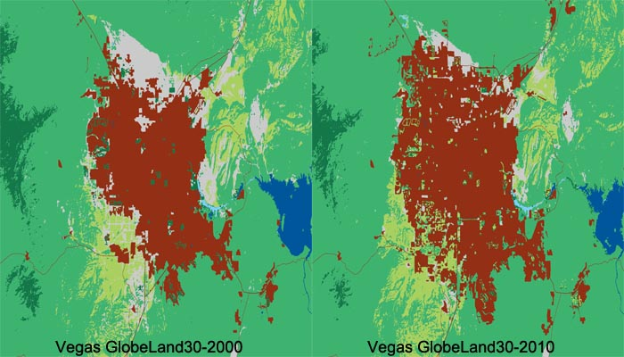

## 1. Installing

Before coding do not forget install and load the following packages and remenber that you can communicate with the bash console prepending an ! to the code.

```python
!pip install geopandas #tensorflow 2.0
!pip install earthengine-api==0.1.175 #earthengine API
```

## 2. Authentification

This tutorial needs interacting with others Google services. For accomplish this task, it’s necessary to authenticate (as yourself). The code below shows you how to do it.

- **Google Drive**

We will use Google Drive for save us results.

```python
from google.colab import drive
drive.mount('/content/drive')
```

- **Authenticate to Earth Engine**

```python
!earthengine authenticate
```

## 3. Testing the software setup

```python
# Earth Engine Python API
import ee
ee.Initialize()

import folium
import geopandas as gpd

# Define the URL format used for Earth Engine generated map tiles.
EE_TILES = 'https://earthengine.googleapis.com/map/{mapid}/{{z}}/{{x}}/{{y}}?token={token}'

print('Folium version: ' + folium.__version__)
print('Geopandas version: ' + gpd.__version__)
```

## 4. Display either ee.Image or ee.Feature

```python
def Mapdisplay(center, dicc, Tiles="OpensTreetMap",zoom_start=10):
    '''
    :param center: Center of the map (Latitude and Longitude).
    :param dicc: Earth Engine Geometries or Tiles dictionary
    :param Tiles: Mapbox Bright,Mapbox Control Room,Stamen Terrain,Stamen Toner,stamenwatercolor,cartodbpositron.
    :zoom_start: Initial zoom level for the map.
    :return: A folium.Map object.
    '''
    center = center[::-1]
    mapViz = folium.Map(location=center,tiles=Tiles, zoom_start=zoom_start)
    for k,v in dicc.items():
      if ee.image.Image in [type(x) for x in v.values()]:
        folium.TileLayer(
            tiles = v["tile_fetcher"].url_format,
            attr  = 'Google Earth Engine',
            overlay =True,
            name  = k
          ).add_to(mapViz)
      else:
        folium.GeoJson(
        data = v,
        name = k
          ).add_to(mapViz)
    mapViz.add_child(folium.LayerControl())
    return mapViz
```

## 5. Preparing Geometry Data (Geopandas to EE)

```python
#download the geometry
import urllib
url = 'https://github.com/csaybar/csaybar.github.io/raw/master/data/provinces.geojson'
urllib.request.urlretrieve(url, 'Peru.geojson')
```

```python
# Reading the file
peruprov = gpd.read_file('Peru.geojson')
lima = peruprov[peruprov.NOMBRE == 'LIMA'].to_json() # Selecting Lima
lima_coords = eval(lima)['features'][0]['geometry']['coordinates'][0] #getting just the coordinates

# ee.Geometry -> ee.Feature -> ee.FeatureCollection
eeLima = ee.FeatureCollection([ee.Feature(ee.Geometry.Polygon(lima_coords),{'Name':'Lima'})])
```

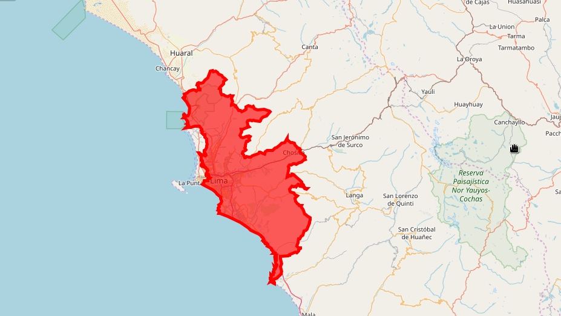

```python
# display the geometry using folium
center_lima = eeLima.geometry().centroid().getInfo()['coordinates']
center_lima.reverse()

fig =eeLima.draw(**{'color': 'FF0000', 'strokeWidth': 5}).getMapId()
Mapdisplay(center_lima,{'Lima':fig})
```

## 6. Reading and clipping the GLC30 dataset

[figure not shown]

```python
# Remove 0 and 255 values (no data)
def removevalues(img):
  value_0 = img.neq(0)
  value_255 = img.neq(255)
  return img.updateMask(value_0).updateMask(value_255).divide(10).int()

# Define a palette for the distinct land cover classes.
glc30Palette = [
  'ff02d0', # 1-Cultaved Lands
  '147749', # 2-Forest
  'a9d05f', # 3-Grassland
  '3eb370', # 4-Shrublands
  '7ecef4', # 5-Wetlands
  '00569a', # 6-Water bodies
  '6f6f6f',  # 7-Tundra
  '911818', # 8-Artificial Surfaces
  'cacaca', # 9-Bareland
  'f9f3c1', # 10-Permanent snow and ice
]

# Load the dataset
glc30_lima = ee.ImageCollection('users/csaybar/GLC30PERU')\
               .map(removevalues).max().clip(eeLima)

vizparams = {'min':1,'max':10,'palette':glc30Palette}
```

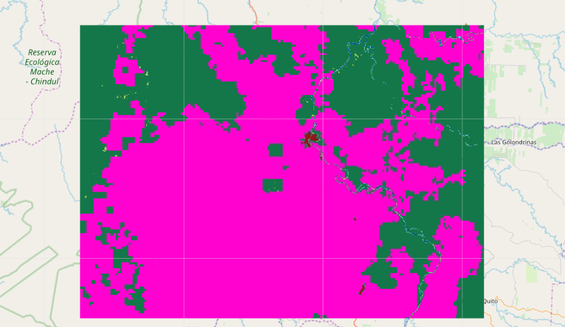

```python
# Ecuador
Ecuador = ee.Geometry.Polygon([[-79.25,0.10],[-79.25,0.47],[-79.76,0.47],[-79.76,0.10], [-79.25,0.10]])
center_ecu = Ecuador.centroid().getInfo()['coordinates']
center_ecu.reverse()
# Load the dataset
glc30_ecuador = ee.ImageCollection('users/csaybar/GLC30PERU')\
               .map(removevalues).max().clip(Ecuador)

vizparams = {'min':1,'max':10,'palette':glc30Palette}
Mapdisplay(center_ecu,{'glc30':glc30_ecuador.getMapId(vizparams)},zoom_start=10)
```

## 7. Export the results of EE to Google Drive

```python
# Export the image, specifying scale and region.
task = ee.batch.Export.image.toDrive(**{
    'image': glc30,
    'description': 'GLC30LIMA',
    'folder':'GLC30',
    'scale': 30,
    'region': eeLima.geometry().getInfo()['coordinates']
})
task.start()
```

Monitoring your Export

```python
import time
while task.active():
  print('Polling for task (id: {}).'.format(task.id))
  time.sleep(5)
```

```python
# Export the image, specifying scale and region.
task = ee.batch.Export.image.toDrive(**{
    'image': glc30,
    'description': 'GLC30ECUADOR',
    'folder':'GLC30',
    'scale': 30,
    'region': Ecuador.getInfo()['coordinates']
})
task.start()
```